# Praca domowa 2

Jerzy Adrjan

## Dane

Dane wykorzystane w Pracy domowej 2 dotyczą wyników egzaminów z 3 umiejętności: czytania, pisania i operacji matematycznych. Dodatkowo dostępne są podstawowe informacje o studentach i ich rodzicach. Opis wszystkich kolumn znajduje się również w pliku `README.md`.

| Zmienna | Opis |
| --- | --- |
| **gender** | płeć |
| **race.ethnicity** | pochodzenie etniczne |
| **parental.level.of.education** | wykształcenie rodziców |
| **lunch** | jaki obiad jedli uczniowie w dniu egzaminu |
| **test.preparation.course** | czy uczeń odbył kurs przygotowujący |
| **math.score** | wynik egzaminu z matematyki |
| **reading.score** | wynik egzaminu z czytania |
| **writing.score** | wynik egzaminu z pisania |

## Zadanie 1

Jak wyglądają rozkłady wyników uczniów z trzech przedmiotów (matematyka, czytanie, pisanie)?

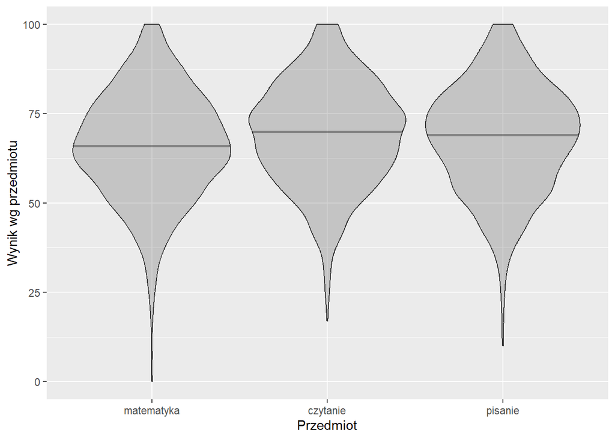

```r
df %>%
  select(matches(".*\\.score")) %>%
  pivot_longer(cols=everything(), names_to="subject", values_to="score") %>%
  mutate(subject=factor(subject, levels=c("math.score", "reading.score", "writing.score"),
                        labels=c("matematyka", "czytanie", "pisanie"))) %>%
  ggplot(mapping=aes(y=score, x=subject)) +
  geom_violin(alpha=0.333, fill="#777",
              quantile.colour="#000", quantile.linewidth=1, quantiles=0.5, quantile.linetype=1) +
  labs(x="Przedmiot", y="Wynik wg przedmiotu")
```

**Komentarz:**

Wyniki z matematyki są średnio najniższe, wyniki z pisania i czytania mają podobny rozkład – wyniki z czytania są nieco wyższe.

## Zadanie 2

Czy istnieje zauważalna różnica w wynikach między uczniami i uczennicami?

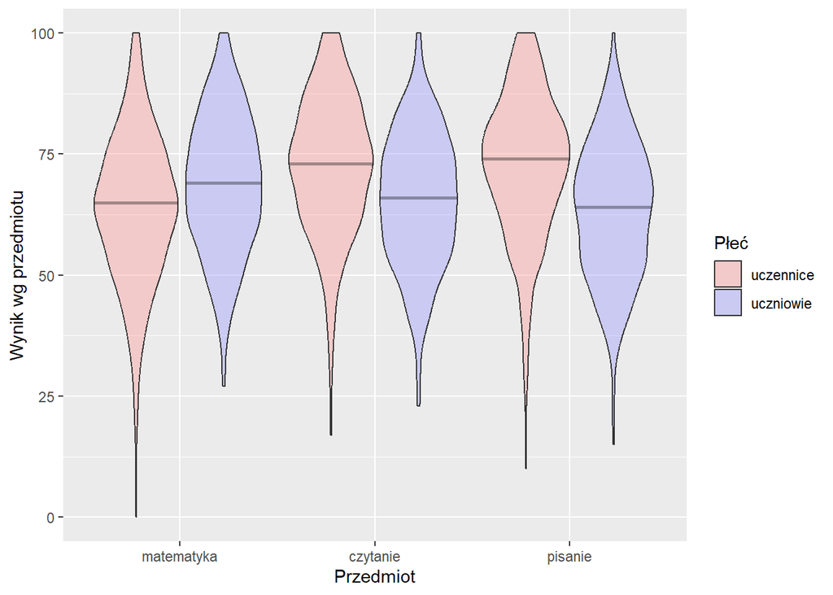

```r
df %>%
  pivot_longer(cols=c("math.score", "reading.score", "writing.score"), names_to="subject", values_to="score") %>%
  mutate(gender=factor(gender, levels=c("female", "male"), labels=c("uczennice", "uczniowie")),
         subject=factor(subject, levels=c("math.score", "reading.score", "writing.score"),
                        labels=c("matematyka", "czytanie", "pisanie"))) %>%
  select(gender, subject, score) %>%
  ggplot(mapping=aes(y=score, x=subject, fill=gender)) +
  geom_violin(alpha=0.333,
              quantile.colour="#000", quantile.linewidth=1, quantiles=0.5, quantile.linetype=1) +
  scale_fill_manual(values=(c("#f88", "#88f"))) +
  labs(x="Przedmiot", y="Wynik wg przedmiotu", fill="Płeć")
```

**Komentarz:**

Tak. Uczniowie (płci męskiej) osiągają wyższe wyniki (mediana wyższa o ok. 5 pkt) z matematyki. Uczennice osiągają znacznie wyższe wyniki (mediana wyższa o ok. 10 pkt) z czytania i pisania.

## Zadanie 3

Czy uczniowie, którzy ukończyli kurs przygotowawczy, osiągają lepsze wyniki niż pozostali?

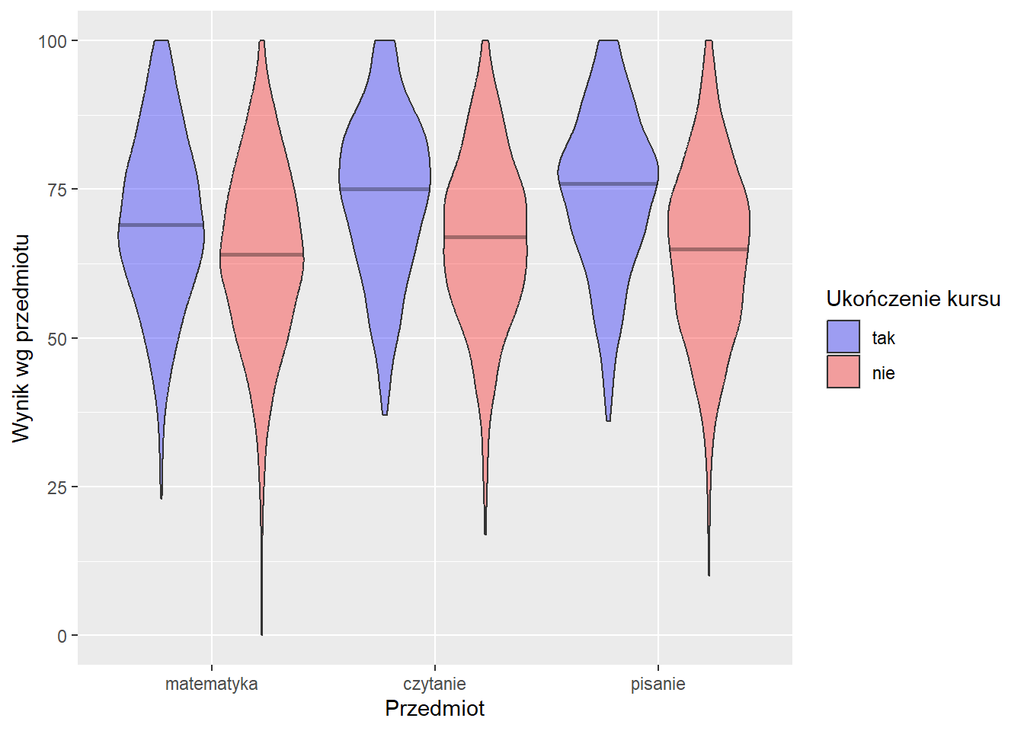

```r
df %>%
  pivot_longer(cols=c("math.score", "reading.score", "writing.score"), names_to="subject", values_to="score") %>%
  mutate(course=factor(test.preparation.course,
                       levels=c("completed", "none"), labels=c("tak", "nie")),
         subject=factor(subject, levels=c("math.score", "reading.score", "writing.score"),
                        labels=c("matematyka", "czytanie", "pisanie"))) %>%
  select(course, subject, score) %>%
  ggplot(mapping=aes(y=score, x=subject, fill=course)) +
  geom_violin(alpha=0.333,
              quantile.colour="#000", quantile.linewidth=1, quantiles=0.5, quantile.linetype=1) +
  scale_fill_manual(values=(c("#00f", "#f00"))) +
  labs(x="Przedmiot", y="Wynik wg przedmiotu", fill="Ukończenie kursu")
```

**Komentarz:**

Tak. Wyniki po ukończeniu kursu przygotowawczego są znacznie wyższe – ok. 5 pkt z matematyki, ok. 10 pkt z czytania, ok. 12 pkt z pisania. Dodatkowo dystrybucja wyników po ukończeniu kursu przygotowawczego zawiera znacznie mniej wyników bardzo słabych i więcej wyników w okolicach 100%.

## Zadanie 4

Jaki jest związek między poziomem wykształcenia rodziców a średnimi wynikami uczniów?

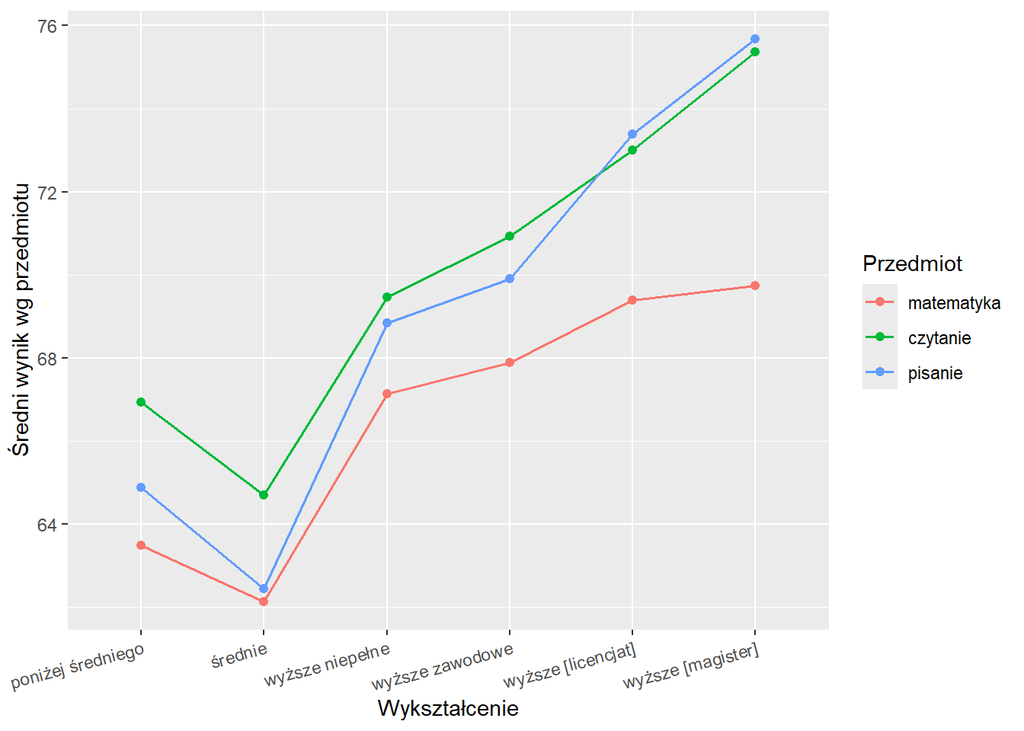

```r
df %>%
  mutate(education=factor(parental.level.of.education,
                          levels=c("some high school", "high school", "some college", "associate's degree", "bachelor's degree", "master's degree"),
                          labels=c("poniżej średniego", "średnie", "wyższe niepełne", "wyższe zawodowe", "wyższe [licencjat]", "wyższe [magister]"))) %>%
  select(education, matches(".*\\.score")) %>%
  pivot_longer(cols=!education, names_to="subject", values_to="score") %>%
  group_by(education, subject) %>%
  summarise(mean=mean(score)) %>%
  mutate(subject=factor(subject,
                        levels=c("math.score", "reading.score", "writing.score"),
                        labels=c("matematyka", "czytanie", "pisanie"))) %>%
  ggplot(mapping=aes(x=education, y=mean, colour=subject, group=subject)) +
  geom_line(linewidth=0.57) +
  geom_point(size=1.75) +
  theme(axis.text.x = element_text(angle = 15, hjust = 1)) +
  labs(x="Wykształcenie", y="Średni wynik wg przedmiotu", colour="Przedmiot")
```

**Komentarz:**

Wyniki rosną wraz ze wzrostem wykształcenia rodziców (poza wykształceniem poniżej średniego, dla którego wyniki są powyżej “średniego”). Efekt jest bardziej zauważalny w wynikach z czytania i pisania, mniej z matematyki, gdzie wzrost spowalnia dla dalszych kroków w wykształceniu wyższym.

## Zadanie 5

Czy płeć i wykształcenie rodzica wpływa na wynik z matematyki?

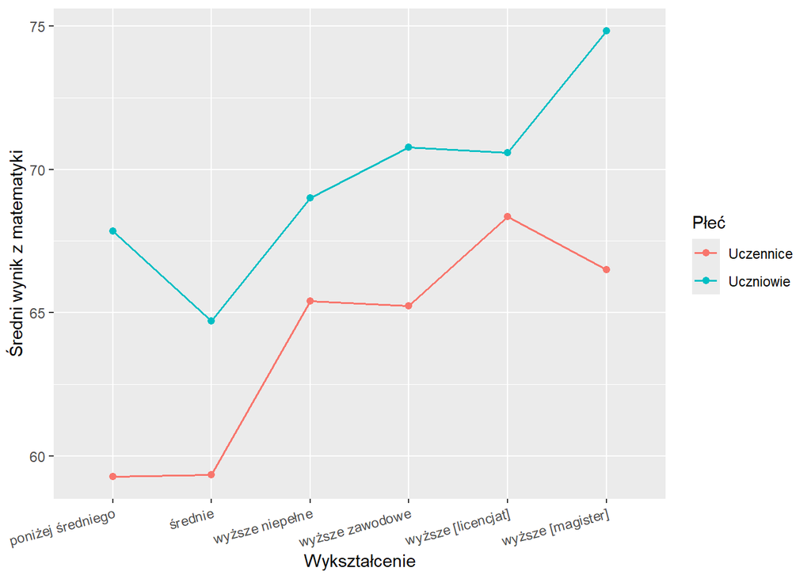

```r
df %>%
  mutate(education=factor(parental.level.of.education, levels=c("some high school", "high school", "some college", "associate's degree", "bachelor's degree", "master's degree"),
                          labels=c("poniżej średniego", "średnie", "wyższe niepełne", "wyższe zawodowe", "wyższe [licencjat]", "wyższe [magister]")),
         gender=factor(gender, levels=c("female", "male"), labels=c("Uczennice", "Uczniowie"))) %>%
  select(education, gender, math.score) %>%
  group_by(education, gender) %>%
  summarise(mean=mean(math.score)) %>%
  ggplot(mapping=aes(x=education, y=mean, colour=gender, group=gender)) +
  geom_line(linewidth=0.57) +
  geom_point(size=1.75) +
  theme(axis.text.x = element_text(angle = 15, hjust = 1)) +
  labs(x="Wykształcenie", y="Średni wynik z matematyki", colour="Płeć")
```

**Komentarz:**

Zarówno płeć ucznia, jak i wykształcenie rodzica wpływają na wyniki z matematyki. Uczniowie (płci męskiej) osiągają wyższe wyniki, niż uczennice. Im wyższy poziom wykształcenia rodzica, tym wyższe wyniki z matematyki, jednak wpływ nie jest równy dla obu płci. Uczniowie, których rodzice osiągnęli poziom magistra, mają znacznie wyższe wyniki od innych, u uczennic obserwowany jest spadek z poziomu licencjatu.

## Zadanie 6

Czy istnieje zależność między wynikami z matematyki a wynikami z czytania lub pisania?

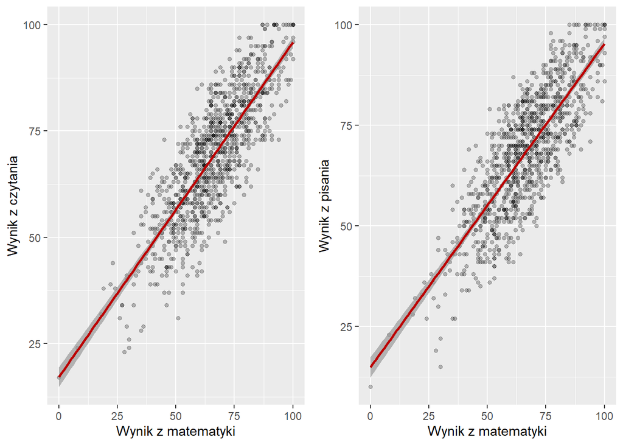

```r
plot.reading = df %>%
  ggplot(mapping=aes(x=math.score, y=reading.score)) +
  geom_point(size=1.2, alpha=0.25) +
  geom_smooth(method = "lm", se = TRUE, colour = "#b00", alpha=0.7) +
  labs(x="Wynik z matematyki", y="Wynik z czytania")

plot.writing = df %>%
  ggplot(mapping=aes(x=math.score, y=writing.score)) +
  geom_point(size=1.2, alpha=0.25) +
  geom_smooth(method = "lm", se = TRUE, colour = "#b00", alpha=0.7) +
  labs(x="Wynik z matematyki", y="Wynik z pisania")

gridExtra::grid.arrange(plot.reading, plot.writing, ncol=2)
```

**Komentarz:**

Wyniki z matematyki są znacząco skorelowane z wynikami z pozostałych przedmiotów. Obecna jest wyraźna zależność – wyniki z czytania i pisania rosną, kiedy rosną wyniki z matematyki. Wynikowi 50% z matematyki odpowiada ok. 56% z czytania i pisania.